# Import libraries

## Other features

### Age vs Credit Score

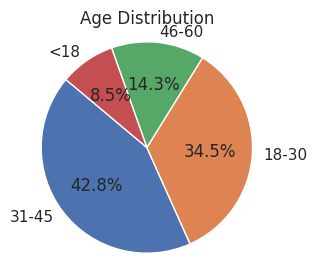

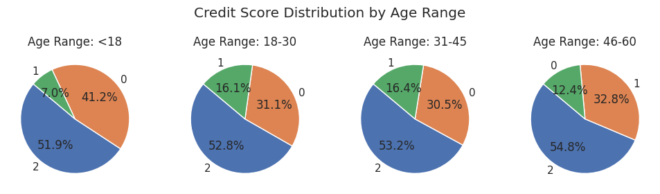

```python
bins = [0, 18, 30, 45, 60]
labels = ['<18', '18-30', '31-45', '46-60']
transformed_df['age_group'] = pd.cut(transformed_df['age'], bins=bins, labels=labels)

age_credit_scores = {}

age_group_counts = transformed_df['age_group'].value_counts()

plt.figure(figsize=(3, 3))
plt.pie(age_group_counts, labels=age_group_counts.index, autopct='%1.1f%%', startangle=140)
plt.title('Age Distribution')
plt.axis('equal')
plt.show()

for age_range in labels:
    age_range_df = transformed_df[transformed_df['age_group'] == age_range]
    credit_score_counts = age_range_df['credit_score'].value_counts()
    age_credit_scores[age_range] = credit_score_counts


fig, axes = plt.subplots(2, 4, figsize=(10, 5))
fig.suptitle("Credit Score Distribution by Age Range")


for i, (age_range, credit_score_counts) in enumerate(age_credit_scores.items()):
    ax = axes[i // 4, i % 4]
    ax.pie(credit_score_counts, labels=credit_score_counts.index, autopct='%1.1f%%', startangle=140)
    ax.set_title(f'Age Range: {age_range}')


for i in range(len(labels), 8):
    fig.delaxes(axes[i // 4, i % 4])

plt.tight_layout()
plt.show()
```

### Occupation

Represents the occupation of the person. In previous section, we had update occupation into columns that represents specific jobs: architect, developer, doctor, engineer, entrepreneur, journalist, lawyer, manager, mechanic, media_manager, musician, scientist, teacher and writer.

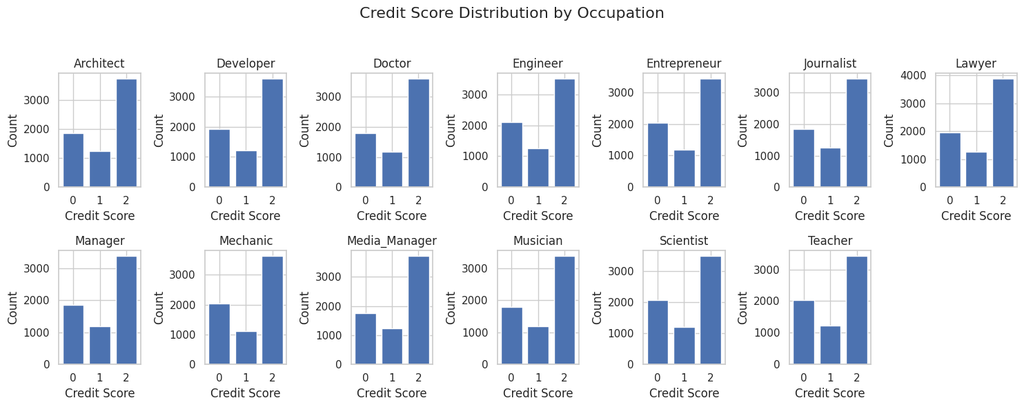

```python
# List of occupations
occupations = [
    'Architect', 'Developer', 'Doctor', 'Engineer', 'Entrepreneur',
    'Journalist', 'Lawyer', 'Manager', 'Mechanic', 'Media_Manager',  # Corrected occupation name
    'Musician', 'Scientist', 'Teacher', 'Writer'
]

# Set up the subplot grid
fig, axes = plt.subplots(2, 7, figsize=(15, 6))
fig.suptitle('Credit Score Distribution by Occupation', fontsize=16)

# Iterate through occupations and create bar charts
for i, occupation in enumerate(occupations):
    ax = axes[i // 7, i % 7]

    # Filter data for the specific occupation
    occupation_data = transformed_df[transformed_df[f'occupation_{occupation.lower()}'] == 1]

    # Calculate the proportions of each credit score category
    credit_score_counts = occupation_data['credit_score'].value_counts().sort_index()

    # Create a bar chart for the occupation
    ax.bar(credit_score_counts.index, credit_score_counts.values)
    ax.set_title(occupation)
    ax.set_xticks(credit_score_counts.index)
    ax.set_xlabel('Credit Score')
    ax.set_ylabel('Count')

# Remove the unused subplot
fig.delaxes(axes[1, 6])

# Adjust layout
plt.tight_layout(rect=[0, 0, 1, 0.95])
plt.show()
```

The analysis of credit score distributions across a diverse range of occupations reveals a striking and consistent similarity in the patterns. Regardless of the specific profession, the visualizations consistently portray a notable resemblance, with credit scores distributed in a manner that remains largely consistent across various job categories. This finding suggests that, when it comes to credit scoring, the occupation of an individual may not significantly influence the overall distribution of credit scores, emphasizing the role of other factors in determining creditworthiness.

### Payment Behavior

Represents the payment behavior of the custormer (int USD): hight_spent_medium_value_payments, hight_spent_small_value_payments, low_spent_large_value_payments, low_spent_medium_value_payments, low_spent_small_payments.

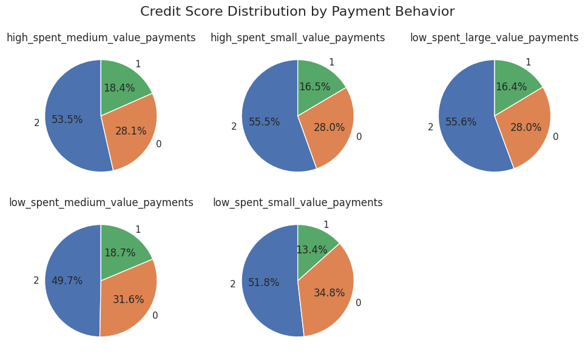

```python
payment_columns = [
    'high_spent_medium_value_payments', 'high_spent_small_value_payments',
    'low_spent_large_value_payments', 'low_spent_medium_value_payments',
    'low_spent_small_value_payments'
]

# Create subplots for each payment behavior with unique percentage values
fig, axes = plt.subplots(2, 3, figsize=(10, 6))
fig.suptitle('Credit Score Distribution by Payment Behavior', fontsize=16)

# Iterate through payment columns and create pie charts
for i, payment_column in enumerate(payment_columns):
    row, col = divmod(i, 3)
    ax = axes[row, col]

    # Filter data for the specific payment behavior
    payment_data = transformed_df[transformed_df[payment_column] == 1]

    # Calculate the count of each credit score category
    credit_score_counts = payment_data['credit_score'].value_counts()

    # Create a pie chart for the payment behavior
    ax.pie(credit_score_counts, labels=credit_score_counts.index, autopct='%1.1f%%', startangle=90)
    ax.set_title(payment_column)

fig.delaxes(axes[1, 2])
# Adjust layout
plt.tight_layout()
plt.show()
```

The figures shown that in mostly all payment behaviors, leading to Standard credit scores has the highest probability and then Poor credit scores. Good credit scores just take around less 20% for each payment behavior.

### Payment of Min amount

This represents whether only the minimum amount was paid by the person (Yes or No).

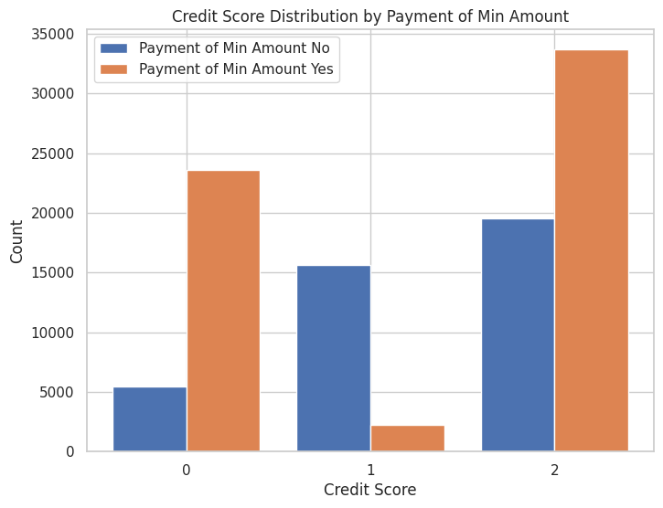

```python
payment_data = transformed_df[['credit_score', 'payment_of_min_amount_yes']]

# Group data by credit score and payment status, and calculate counts
grouped_data = payment_data.groupby(['credit_score', 'payment_of_min_amount_yes']).size().unstack(fill_value=0)
grouped_data.columns = ['Payment of Min Amount No', 'Payment of Min Amount Yes']

# Create the bar chart
fig, ax = plt.subplots(figsize=(8, 6))
x = range(3)
width = 0.4

for col in grouped_data.columns:
    ax.bar(x, grouped_data[col], width, label=col, align='center')
    x = [i + width for i in x]

ax.set_xlabel('Credit Score')
ax.set_ylabel('Count')
ax.set_title('Credit Score Distribution by Payment of Min Amount')
ax.set_xticks([i + width / 2 for i in range(3)])
ax.set_xticklabels(['0', '1', '2'])
ax.legend()

plt.show()
```

The pattern of individuals who did not pay the minimum amount having good credit scores, while those who paid only the minimum amount being divided into poor and standard credit score categories, can be attributed to differences in financial behavior and circumstances. Not paying the minimum amount may indicate responsible financial management, where individuals avoid accumulating debt and thus maintain good credit scores. Conversely, those who pay only the minimum may include a diverse range of financial profiles, with some facing financial constraints that lead to poor credit scores, while others, with a more stable financial track record, may maintain standard credit scores. It is important to remember that credit scores are determined by a combination of factors, making each individual's creditworthiness unique and influenced by various financial elements beyond just minimum payments.

### Type of Loan

This represents the types of loan taken by a person: home equity loan, not specified loan, debt consolidation loan, payday loan, student loan, mortgage loan, credit-builder loan, auto loan, personal loan,

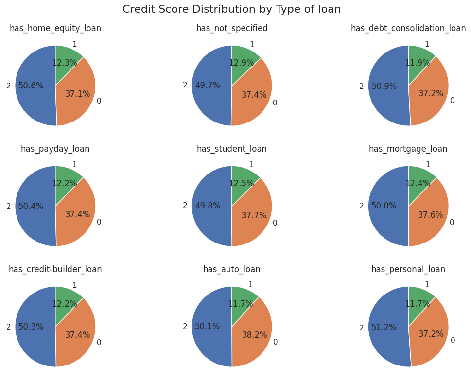

```python
loan_columns = [
    'has_home_equity_loan', 'has_not_specified',
    'has_debt_consolidation_loan', 'has_payday_loan',
    'has_student_loan','has_mortgage_loan','has_credit-builder_loan','has_auto_loan','has_personal_loan'
]

# Create separate pie charts for each payment behavior with unique percentage values
fig, axes = plt.subplots(3, 3, figsize=(12, 8))
fig.suptitle('Credit Score Distribution by Type of loan', fontsize=16)

# Iterate through payment columns and create pie charts
for i, loan_column in enumerate(loan_columns):
    row, col = divmod(i, 3)
    ax = axes[row, col]

    # Filter data for the specific payment behavior
    loan_data = transformed_df[transformed_df[loan_column] == 1]

    # Calculate the count of each credit score category
    credit_score_counts = loan_data['credit_score'].value_counts()

    # Create a pie chart for the payment behavior
    ax.pie(credit_score_counts, labels=credit_score_counts.index, autopct='%1.1f%%', startangle=90)
    ax.set_title(loan_column)

# Adjust layout
plt.tight_layout()
plt.show()
```

Across the spectrum of various loan types, a remarkable consistency emerges as approximately half of the individuals within each specific loan category exhibit standard credit scores, while nearly 40% of borrowers in these categories tend to hold poor credit scores. The occurrence of individuals with good credit scores remains notably scarce across the board. This commonality underscores a uniform trend in the distribution of credit scores, suggesting that regardless of the type of loan, a substantial proportion of borrowers fall within the standard or poor credit range, emphasizing the importance of understanding the underlying factors that contribute to this shared pattern.

### changed_credit_limit

This shown the percentage of change in the limitation of a credit accounts.

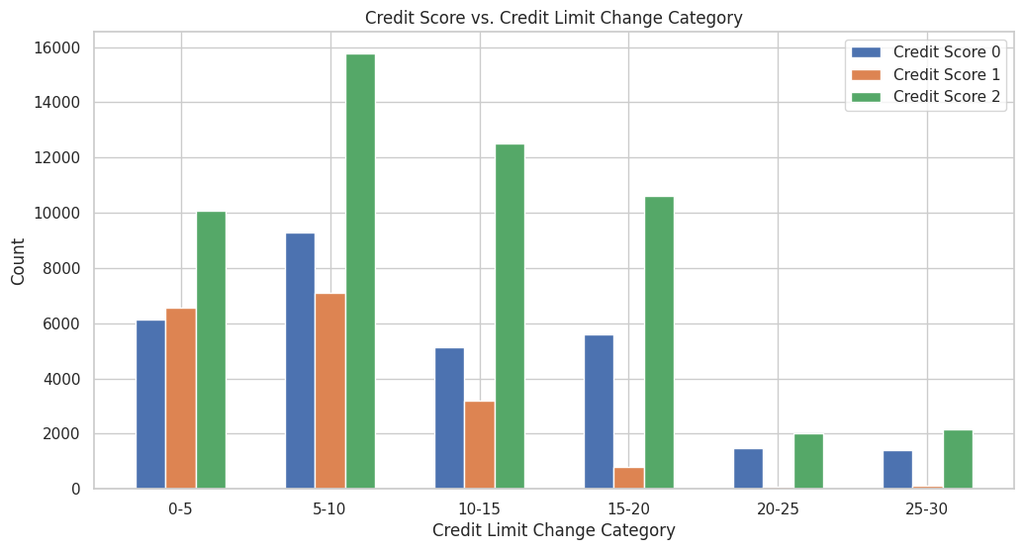

```python
changed_credit_limit=transformed_df['changed_credit_limit']
credit_scores=transformed_df['credit_score']

credit_limit_categories = ['0-5', '5-10', '10-15', '15-20', '20-25', '25-30']

# Create dictionaries to count occurrences of each credit score for each category
credit_score_counts = {category: {'0': 0, '1': 0, '2': 0} for category in credit_limit_categories}

for i in range(len(changed_credit_limit)):
    for category in credit_limit_categories:
        if category.startswith('<'):
            upper_limit = float(category[1:-1])
            if changed_credit_limit[i] < upper_limit:
                credit_score_counts[category][str(credit_scores[i])] += 1
        else:
            lower, upper = map(float, category.split('-'))
            if lower <= changed_credit_limit[i] < upper:
                credit_score_counts[category][str(credit_scores[i])] += 1

# Create a grouped bar plot
plt.figure(figsize=(12, 6))

bar_width = 0.2
categories = list(credit_score_counts.keys())
credit_score_0 = [credit_score_counts[category]['0'] for category in categories]
credit_score_1 = [credit_score_counts[category]['1'] for category in categories]
credit_score_2 = [credit_score_counts[category]['2'] for category in categories]

x = range(len(categories))
plt.bar(x, credit_score_0, width=bar_width, label='Credit Score 0')
plt.bar([i + bar_width for i in x], credit_score_1, width=bar_width, label='Credit Score 1')
plt.bar([i + 2 * bar_width for i in x], credit_score_2, width=bar_width, label='Credit Score 2')

plt.title("Credit Score vs. Credit Limit Change Category")
plt.xlabel("Credit Limit Change Category")
plt.ylabel("Count")
plt.xticks([i + bar_width for i in x], categories)
plt.legend()

plt.show()
```

## Heat map

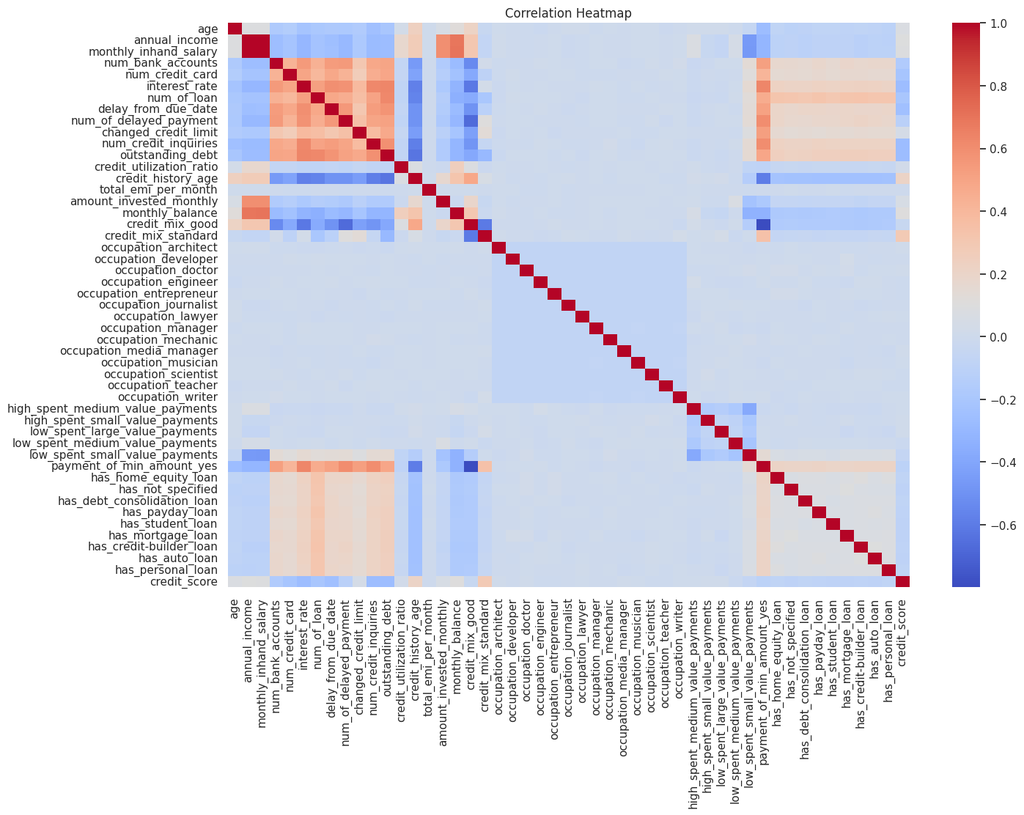

```python
plt.figure(figsize=(15, 10))
sns.heatmap(transformed_df.corr(), cmap='coolwarm', annot=False)
plt.title('Correlation Heatmap')
plt.show()
```

# Create and train machine learning models

## Split into train/test

```python
y = transformed_df['credit_score'].copy()
X = transformed_df.drop('credit_score', axis=1)
```

```python
from sklearn.model_selection import train_test_split
X_train, X_test, y_train, y_test = train_test_split(
    X, y, test_size=0.2, random_state=42)
```

```python
print("X_train.shape: ", X_train.shape)
print("X_test.shape: ", X_test.shape)
```

[output not shown]

```python
y_train.value_counts(normalize=True)
```

```
credit_score
2    0.532188
0    0.289050
1    0.178762
Name: proportion, dtype: float64
```

```python
from imblearn.over_sampling import SMOTE
rus = SMOTE(sampling_strategy='auto')
X_train, y_train = rus.fit_resample(X_train, y_train)
```

```python
y_train.value_counts(normalize=True)
```

```
credit_score
2    0.333333
1    0.333333
0    0.333333
Name: proportion, dtype: float64
```

## Import and define funtions

```python
from sklearn.preprocessing import StandardScaler
from sklearn.preprocessing import PowerTransformer
from sklearn.pipeline import Pipeline
from sklearn.svm import SVC
from sklearn.neural_network import MLPClassifier
from sklearn.linear_model import LogisticRegression
from sklearn.naive_bayes import GaussianNB
from sklearn.ensemble import RandomForestClassifier
from sklearn.model_selection import GridSearchCV
from xgboost import XGBClassifier
from sklearn.ensemble import (
    BaggingClassifier,
    ExtraTreesClassifier,
    StackingClassifier,
    HistGradientBoostingClassifier
)
import itertools
```

```python
def generate_pipes(pipe_config):
    pipe_config = [list(step.items()) for _, step in pipe_config]
    pipe_config = list(itertools.product(*pipe_config))
    pipe_names = list(map(lambda steps: [name for name,_ in steps], pipe_config))
    pipe_names = list(map(lambda L: ">".join(L), pipe_names))
    pipes = [Pipeline(cfg) for cfg in pipe_config]
    return dict(zip(pipe_names, pipes))

def find_hyperparams(pipe_mapper):
  print("Start the tuning process ...")
  best_pipes = {}
  results = []
  for idx, pipe_name in enumerate(list(pipe_mapper.keys())):
    print(f"{idx + 1}. Tuning pipe: {pipe_name}")

    # Select parameters related to the current pipeline:
    param_grid = {}
    for step_name in pipe_name.split('>'):
      for param_name in parameters.keys():
        if param_name.startswith(step_name):
          param_grid[param_name] = parameters[param_name]

    # Create a finder and search for the best parameters
    pipe = pipe_mapper[pipe_name]
    # Specify scoring as a list to use multiple scoring metrics
    finder = GridSearchCV(pipe, param_grid=param_grid, cv=2,
                          scoring=['accuracy', 'f1_macro'],  # Use both accuracy and F1 score
                          refit='f1_macro',  # Choose the best model based on F1 score
                          return_train_score=True)

    finder.fit(X_train, y_train)
    print("\t best-params: {:>15s}".format(str(finder.best_params_)))
    print("\t best-accuracy: {:>16.4f}".format(finder.cv_results_['mean_test_accuracy'][finder.best_index_]))
    macro_f1 = finder.score(X_train, y_train)  # Calculate macro-averaged F1 from best estimator
    print("\t best-macro-f1: {:>16.4f}".format(macro_f1))
    print()

    # Store the best pipe
    best_pipes[pipe_name] = finder.best_estimator_

    # Add results to a dataframe
    rs_item = {"Method": pipe_name, "Accuracy": finder.cv_results_['mean_test_accuracy'][finder.best_index_], "Macro F1": macro_f1}
    for key, value in finder.best_params_.items():
      rs_item[key] = value
    results.append(rs_item)

  print("The tuning is done!")
  tuned_table = pd.DataFrame(results)
  tuned_table.set_index('Method')
  return tuned_table, best_pipes
```

## Define pipeplines

```python
# Define methods for scaling features
scalers = {
    "PowerTransformer": PowerTransformer(method='yeo-johnson', standardize=True),
    "StandardScaler": StandardScaler(),
}


# Define methods for classifying samples
classifiers = {
    "LogisticRegression": LogisticRegression(max_iter=3000),
    "MLPClassifier": MLPClassifier(max_iter=1000),
    "SVC": SVC(max_iter=3000),
    "RandomForestClassifier": RandomForestClassifier(max_depth=10, n_jobs=-1),
    "GaussianNB": GaussianNB(),
    "StackingClassifier": StackingClassifier([
    ('bagging', BaggingClassifier(n_jobs=-1)),
    ('extraTress', ExtraTreesClassifier(max_depth=10, n_jobs=-1)),
    ('randomforest', RandomForestClassifier(n_jobs=-1)),
    ('histGradientBoosting', HistGradientBoostingClassifier()),
    ('XGB', XGBClassifier(n_jobs=-1))
], n_jobs=-1)
}

pipe_steps = [
    ('scaler', scalers),
    ('classifier', classifiers)
]

# Define parameters for each method
parameters = {
    "SVC__kernel": ['rbf'],
    "MLPClassifier__hidden_layer_sizes": [(64,)],
    "MLPClassifier__activation": ['relu'],
    "DecisionTreeClassifier__criterion": ['entropy'],
    "RandomForestClassifier__n_estimators": [50, 100],
    "RandomForestClassifier__criterion": ['entropy'],
}
```

## Tune hyper-parameters

### Keeping all the feature

```python
pipe_mapper = generate_pipes(pipe_steps)
tuned_table, best_pipes = find_hyperparams(pipe_mapper)
```

```python
# Save to file
tuned_table.to_csv("/home/sirius/Documents/Data Mining/tuned_results.csv", sep=";")
```

```python
tuned_table[['Method', 'Accuracy', 'Macro F1']]
```

|  | Method | Accuracy | Macro F1 |
| --- | --- | --- | --- |
| 0 | PowerTransformer>LogisticRegression | 0.706283 | 0.711979 |
| 1 | PowerTransformer>MLPClassifier | 0.754222 | 0.803937 |
| 2 | PowerTransformer>SVC | 0.636101 | 0.564470 |
| 3 | PowerTransformer>RandomForestClassifier | 0.756414 | 0.753181 |
| 4 | PowerTransformer>GaussianNB | 0.703277 | 0.706936 |
| 5 | PowerTransformer>StackingClassifier | 0.842278 | 0.990528 |
| 6 | StandardScaler>LogisticRegression | 0.705062 | 0.711765 |
| 7 | StandardScaler>MLPClassifier | 0.753768 | 0.800645 |
| 8 | StandardScaler>SVC | 0.635952 | 0.592791 |
| 9 | StandardScaler>RandomForestClassifier | 0.756923 | 0.754598 |
| 10 | StandardScaler>GaussianNB | 0.705547 | 0.707126 |
| 11 | StandardScaler>StackingClassifier | 0.842114 | 0.990560 |

```python
# Best pipeline:
tuned_table[tuned_table["Accuracy"] == tuned_table["Accuracy"].max()].dropna(axis=1)
```

|  | Method | Accuracy | Macro F1 |
| --- | --- | --- | --- |
| 5 | PowerTransformer>StackingClassifier | 0.842278 | 0.990528 |

```python
# Show the selected pipe
selected_pipe_name = tuned_table.Method[tuned_table["Accuracy"].argmax()]
print(f"Name of the best pipe: {selected_pipe_name}")
selected_pipe = best_pipes[selected_pipe_name]
```

```
Name of the best pipe: PowerTransformer>StackingClassifier
```

### Base on visualization, eliminate non-considerable feature

```python
keeping_columns = ['age', 'annual_income', 'num_bank_accounts',
        'num_credit_card', 'interest_rate', 'num_of_loan',
        'delay_from_due_date', 'num_of_delayed_payment', 'changed_credit_limit',
        'num_credit_inquiries', 'outstanding_debt', 'credit_utilization_ratio',
        'credit_history_age', 'total_emi_per_month', 'amount_invested_monthly',
        'monthly_balance', 'credit_mix_good', 'credit_mix_standard',
        'payment_of_min_amount_yes', 'has_home_equity_loan',
        'has_not_specified', 'has_debt_consolidation_loan', 'has_payday_loan',
        'has_student_loan', 'has_mortgage_loan', 'has_credit-builder_loan',
        'has_auto_loan', 'has_personal_loan']
X = X[keeping_columns]
```

```python
pipe_mapper = generate_pipes(pipe_steps)
tuned_table, best_pipes = find_hyperparams(pipe_mapper)
```

```
Start the tuning process ...
1. Tuning pipe: PowerTransformer>LogisticRegression
	 best-params:              {}
	 best-accuracy:           0.7051
	 best-macro-f1:           0.7118

2. Tuning pipe: PowerTransformer>MLPClassifier
	 best-params: {'MLPClassifier__activation': 'relu', 'MLPClassifier__hidden_layer_sizes': (64,)}
	 best-accuracy:           0.7459
	 best-macro-f1:           0.7773

3. Tuning pipe: PowerTransformer>SVC
	 best-params: {'SVC__kernel': 'rbf'}
	 best-accuracy:           0.5481
	 best-macro-f1:           0.4753

4. Tuning pipe: PowerTransformer>RandomForestClassifier
	 best-params: {'RandomForestClassifier__criterion': 'entropy', 'RandomForestClassifier__n_estimators': 50}
	 best-accuracy:           0.7600
	 best-macro-f1:           0.7601

5. Tuning pipe: PowerTransformer>GaussianNB
	 best-params:              {}
	 best-accuracy:           0.7139
	 best-macro-f1:           0.7093

6. Tuning pipe: PowerTransformer>StackingClassifier
	 best-params:              {}
	 best-accuracy:           0.8375
	 best-macro-f1:           0.9943

7. Tuning pipe: StandardScaler>LogisticRegression
	 best-params:              {}
	 best-accuracy:           0.7050
	 best-macro-f1:           0.7121

8. Tuning pipe: StandardScaler>MLPClassifier
	 best-params: {'MLPClassifier__activation': 'relu', 'MLPClassifier__hidden_layer_sizes': (64,)}
	 best-accuracy:           0.7383
	 best-macro-f1:           0.7807

9. Tuning pipe: StandardScaler>SVC
	 best-params: {'SVC__kernel': 'rbf'}
	 best-accuracy:           0.5141
	 best-macro-f1:           0.5770

10. Tuning pipe: StandardScaler>RandomForestClassifier
	 best-params: {'RandomForestClassifier__criterion': 'entropy', 'RandomForestClassifier__n_estimators': 50}
	 best-accuracy:           0.7613
	 best-macro-f1:           0.7580

11. Tuning pipe: StandardScaler>GaussianNB
	 best-params:              {}
	 best-accuracy:           0.7131
	 best-macro-f1:           0.7082

12. Tuning pipe: StandardScaler>StackingClassifier
	 best-params:              {}
	 best-accuracy:           0.8380
	 best-macro-f1:           0.9941

The tuning is done!
```

```python
# Save to file
tuned_table.to_csv("/home/sirius/Documents/Data Mining/tuned_drop_results.csv", sep=";")
```

```python
tuned_table[['Method', 'Accuracy', 'Macro F1']]
```

|  | Method | Accuracy | Macro F1 |
| --- | --- | --- | --- |
| 0 | PowerTransformer>LogisticRegression | 0.705124 | 0.711819 |
| 1 | PowerTransformer>MLPClassifier | 0.745947 | 0.777348 |
| 2 | PowerTransformer>SVC | 0.548091 | 0.475349 |
| 3 | PowerTransformer>RandomForestClassifier | 0.759961 | 0.760104 |
| 4 | PowerTransformer>GaussianNB | 0.713909 | 0.709322 |
| 5 | PowerTransformer>StackingClassifier | 0.837471 | 0.994279 |
| 6 | StandardScaler>LogisticRegression | 0.704952 | 0.712070 |
| 7 | StandardScaler>MLPClassifier | 0.738250 | 0.780671 |
| 8 | StandardScaler>SVC | 0.514112 | 0.576950 |
| 9 | StandardScaler>RandomForestClassifier | 0.761284 | 0.757961 |
| 10 | StandardScaler>GaussianNB | 0.713087 | 0.708156 |
| 11 | StandardScaler>StackingClassifier | 0.837965 | 0.994059 |

```python
# Show the selected pipe
selected_pipe_name = tuned_table.Method[tuned_table["Accuracy"].argmax()]
print(f"Name of the best pipe: {selected_pipe_name}")
selected_pipe = best_pipes[selected_pipe_name]
```

```
Name of the best pipe: StandardScaler>StackingClassifier
```

# Evaluate the models and improve the model

### Keeping all the feature

```python
from sklearn.metrics import classification_report

print("Start the evaluation process ...")
y_pred = selected_pipe.predict(X_test)
print(classification_report(y_test, y_pred))
print("The evaluation is done!")
```

[output not shown]

### Base on visualization, eliminate non-considerable feature

```python
from sklearn.metrics import classification_report

print("Start the evaluation process ...")
y_pred = selected_pipe.predict(X_test)
print(classification_report(y_test, y_pred))
print("The evaluation is done!")
```

```
Start the evaluation process ...
              precision    recall  f1-score   support

           0       0.79      0.85      0.82      5874
           1       0.76      0.79      0.77      3527
           2       0.84      0.79      0.81     10599

    accuracy                           0.81     20000
   macro avg       0.79      0.81      0.80     20000
weighted avg       0.81      0.81      0.81     20000

The evaluation is done!
```

# Related Work

After researching on Credit Scoring, we found out a related paper that has significant results in this field:

[”Classification methods applied to credit scoring: A systematic review and overall comparison” - Francisco Louzada, Anderson Ara, Guilherme B. Fernandes, published in 5 Feb 2016.](https://arxiv.org/pdf/1602.02137.pdf?fbclid=IwAR3z2W3iHrGTl7IZQESB1112hFCtH5Y6Kw4yMAE0OpePDrgRU6vqeT-Fah0)

This paper present a systematic literature review relating theory and application of binary classification techniques for credit scoring financial analysis. The general results show the use and importance of the main techniques for credit rating, as well as some of the scientific paradigm changes throughout the years. The authors express their intent to conduct a systematic literature review spanning more than two decades, covering 187 papers and including various binary classification techniques for credit scoring. They also plan to conduct an experimental simulation study under nine general methodologies, aiming to summarize findings and provide guidance for researchers interested in credit scoring techniques.

The main classification methods in credit scoring that we can use is:

- Neural networks (NN)
- Logistic regression (LOGISTIC)
- Support vector machine (SVM)
- Naive Bayes (NB)
- Decision trees (TREES)
- Linear discriminant analysis (LDA)
- Linear regression (LREG) (eliminated for poor result)
- Fuzzy logic (FUZZY) (eliminated for long response)
- Genetic programming (GENETIC) (eliminated for long response and poor result)

We also propose a new method that is Stacking Classifier that use the prediction of many classifiers to predict the final result of the task. Based on the analysis and results of the paper and our proposed method. There are our results compare to the paper results (balanced data):

[figure not shown]

```python
tuned_table.sort_values(by=['Macro F1'], ascending=False)[['Method', 'Macro F1']]
```

|  | Method | Macro F1 |
| --- | --- | --- |
| 5 | PowerTransformer>StackingClassifier | 0.994279 |
| 11 | StandardScaler>StackingClassifier | 0.994059 |
| 7 | StandardScaler>MLPClassifier | 0.780671 |
| 1 | PowerTransformer>MLPClassifier | 0.777348 |
| 3 | PowerTransformer>RandomForestClassifier | 0.760104 |
| 9 | StandardScaler>RandomForestClassifier | 0.757961 |
| 6 | StandardScaler>LogisticRegression | 0.712070 |
| 0 | PowerTransformer>LogisticRegression | 0.711819 |
| 4 | PowerTransformer>GaussianNB | 0.709322 |
| 10 | StandardScaler>GaussianNB | 0.708156 |
| 8 | StandardScaler>SVC | 0.576950 |
| 2 | PowerTransformer>SVC | 0.475349 |

Compare between the result of the paper propose and our method:

- NN have the second-best result in our problem compares to $6^{th}$ in the paper.
- Trees have the third-best result compares to $3^{th}$ in the paper.
- Logistic Regression have better result compare to the problem proposed in the paper.
- NB and SVM have poorer results than we expect from the paper. In conclusion, our proposed method have the best result compare to the other method that mention in the paper, which have even poorer result in our specific problem.